## MA2102

# Probability and Statistics

#### Lecture-10

# Cumulative Distribution Function

**Definition:**(Cumulative distribution function)
Let $X$ be a random variable defined on $(\Omega,\mathscr{F},P)$, then the function $F_X:\mathbb{R}\to\mathbb{R}$,
defined by, $F_X(x)=P^X(-\infty,x]$$=$$P(X\le x)$$=$$P(\{\omega\in\Omega:X(\omega)\le x\})$
is called Cumulative distribution function($CDF$) of $X$

We are not so good with dealing with set functions(like $P^X$), but we are good with dealing with functions of real variable(like $F_X$) thanks to Calculus.

To study probability distribution $P^X$ of $X$, it is suffices to study the $CDF$ $F_X$ of $X$, as $P^X$ is completely determined by values of $F_X$

*Notation*:

- $F_X(x_0+):=\lim_{x\to x_0+}F_X(x)$ (Right hand limit of $F_X(x)$ at $x_0$)
- $F_X(x_0-):=\lim_{x\to x_0-}F_X(x)$ (Left hand limit of $F_X(x)$ at $x_0$)
- $F_X(\infty):=\lim_{x\to \infty}F_X(x)$ (Upper limit of $F_X(x)$)
- $F_X(-\infty):=\lim_{x\to -\infty}F_X(x)$ (Lower limit of $F_X(x)$)

Let us consider the example of rolling two dice

$\Omega=\{(i,j):i,j\in\{1,2,3,4,5,6\}\}$

$X:\Omega\to\mathbb{R}$ with mapping $(i,j)\mapsto i+j$, then $\mathscr{X}=\{2,3,...,12\}$

$CDF$ of $X$,

$F_X(x)=P^X((-\infty,x])$$=$$P(X\le x)$
$=P^X(\{a\in\mathscr{X}:a\le x\})$ ($\because$ $P^X(-\infty,x]=P^X((-\infty,x]\cap \mathscr{X})$)

$=\sum_{a\in\mathscr{X};a\le x}P^X(\{a\})$

$\therefore$ $F_X(x)=\left\{\begin{matrix} 0&x<2 \\ \frac{1}{36}&2\le x<3 \\ \frac{3}{36}& 3\le x<4\\ \frac{6}{36} & 4\le x<5\\ \frac{10}{36}&5\le x<6 \\ \frac{15}{36} &6\le x<7 \\ \frac{21}{36} &7\le x<8 \\ \frac{26}{36}& 8\le x<9 \\ \frac{30}{36} &9\le x<10 \\ \frac{33}{36} &10\le x<11 \\ \frac{35}{36}&11\le x<12 \\ 1& x\ge 12 \end{matrix}\right.$

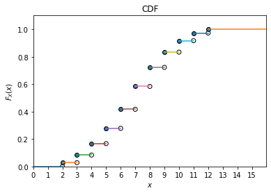

```python
import matplotlib.pyplot as plt

def p(k):   # P^X({k})
    c=0
    for i in [1,2,3,4,5,6]:
        for j in [1,2,3,4,5,6]:
            if(i+j==k):
                c=c+1
    return c/36

def F(x):  #CDF: F_X(x)=P^X({2})+P^X({3})+...+P^X{[x]}  where [x] is greatest integer lessthan or equal to x
    s=0
    for k in range(2,min(x+1,37)):
        s+=p(k)
    return s

fig, ax = plt.subplots()
ax.scatter([x for x in range(2,13)],[F(x-1) for x in range(2,13)], facecolors='none', edgecolors='black')
ax.scatter([x for x in range(2,13)],[F(x) for x in range(2,13)], edgecolors='black')
ax.plot([0,2],[0,0])
for x in range(2,12):
    ax.plot([x,x+1],[F(x),F(x)])
ax.plot([12,16],[1,1])
ax.set_xlim(0,16)
ax.set_ylim(0,1.1)
ax.set_xticks([x for x in range(0,16)])
ax.set_yticks([0,0.2,0.4,0.6,0.8,1.0])
ax.set_ylim(0,1.1)
ax.set_xlabel('$x$')
ax.set_ylabel('$F_X(x)$')
ax.set_title("CDF")
plt.show()
```

In this example,for any $x$ in $\mathscr{X}=\{2,3,4,...,12\}$, we have $F_X(x-)=F_X(x-1)$ ,and $F_X(x+)=F_X(x)$

So, jump length of $F_X$ at $x$=$F(x+)-F(x-)=F(x)-F(x-1)=P^X(\{x\})$ $=P(X=x)$

As we can see that $CDF$ of discrete random variable $X$ happened to be a step function, which has jump discontinuities only at values that $X$ can take,and jump length at a discontinuity $i$ equals to $P(X=i)$ for $i=2,3,...,12$

And we can also observe the following things from above graph  
i. $F_X(x)$ is non-decreasing  
ii. $F_X(x)$ is always right continuous  
iii. Upper limit of $F_X(x)$ is $1$, and Lower limit of $F_X(x)$ is $0$

Let us consider another example that we discussed earlier, that picking number in the interval $[0,1]$

for $0\le a<b\le 1$, $P^X((a,b])=b-a$
now, CDF $F_X(x)=P^X((-\infty,x])=$$P(X\le x)$$=$$P(X\in(-\infty,x])$

for $x\le 0$, $F_X(x)=P^X(-\infty, x]=0$ ($\because$ we never pick negatives)

for $0<x<1$, $F_X(x)=P^X((-\infty,x])$  
$=P^X((-\infty,0]\cup (0,x])$

$=P^X((-\infty,0])+P^X((0,x])=0+(x-0)=x$

for $x\ge 1$, $F_X(x)=P^X((-\infty,x])$

$=P^X((-\infty,0]\cup (0,1]\cup (1,x])$

$=P^X((-\infty,0])+P^X((0,1])+P^X(1,x]=0+(1-0)+0=1$

$\therefore$ $F_X(x)=\left\{\begin{matrix} 0&x\le0 \\ x&0<x< 1 \\ 1& x\ge 1 \end{matrix}\right.$

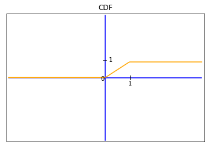

```python
import matplotlib.pyplot as plt
import numpy as np

def F(x):
    y=[]
    for xx in x:
        if xx < 0:
            y.append(0)
        elif xx >= 1:
            y.append(1)
        else:
            y.append(xx)
    return np.array(y)



x=np.linspace(-4,4,100) # Partition of interval [-4,4]

fig, ax = plt.subplots()

ax.plot([-4,4],[0,0],color='blue')
ax.plot([0,0],[-4,4],color='blue')
ax.plot(x,F(x),color='orange')
ax.text(-0.1,1,'-- 1')
ax.text(1,-0.15,'I')
ax.text(0.95,-0.5,'1')
ax.text(-0.2,-0.2,'0')
ax.set_ylim(-4.1,4.1)
ax.set_xlim(-4.1,4.1)
ax.set_xticks([])
ax.set_yticks([])

ax.set_title("CDF")
plt.show()
```

Here we can see that $CDF$ of a continuous random variable happened to be a continuous function, and again following things can be observed.  
i) $F_X(x)$ is non-decreasing  
ii) $F_X(x)$ always right continuous (In fact, here $F_X(x)$ is continuous)  
iii. Upper limit of $F_X(x)$ is $1$, and Lower limit of $F_X(x)$ is $0$

**Facts about Monotone functions of real variable:**

- at any point of $\mathbb{R}$ both the left and right hand limits exists, so they never have a second kind discontinuity, and only type of discontinuity they can have is jump discontinuity.
- set of discontinuity points always either finite or countably infinite, we never have uncountable discontinuities.

**Theorem:** Let $X$ be a random variable with $CDF$ $F_X(x)$, then  
i) $F_X(x)\le F_X(y)$ for $x<y$ ($F_X(x)$ is non-decreasing)  
ii) $F_X(x_0+)=F_X(x_0)~\forall~x_0\in\mathbb{R}$ ($F_X(x)$ is right continuous function)  
iii) $F_X(\infty)=1$ , $F_X(-\infty)=0$(Upper limit of $F_X(x)$ is $1$, and Lower limit of $F_X(x)$ is $0$)

*proof*:

(i) for $x<y$ we have $(-\infty,x]\subset (-\infty,y]$

$\Rightarrow$ $P^X((-\infty,x])\le P^X((-\infty,y])$ ($\because$ Monotone property for $P^X$)

$F_X(x)\le F_X(y)$ ($\because F_X(x)=P^X(-\infty,x])$)

$\therefore$ $F_X(x)$ is non-decreasing function

(ii) Let $x_0$ be an arbitrary real number

Since $F_X(x)$ is non-decreasing (monotone increasing) function, we can be sure about existence right hand limit of $F_X(x_0+)$. (In fact$F_X(x_0-)$ also exists)

now, we want to show that $F_X(x_0+)=F_X(x_0)$

Let $E_n=(-\infty,x_0+\frac{1}{n}]$, then $E_{n+1}\subset E_n$ for $n=1,2,3,...$ i.e $\{E_n\}(\searrow)$

and $(-\infty,x_0]=\bigcap_{n=1}^{\infty}E_n$

$P^X((-\infty,x_0])=P^X(lim_{n\to\infty}E_n)$ ($\because \bigcap_{n=1}^{\infty}E_n=lim_{n\to\infty}E_n$)

$=\lim_{n\to\infty}P^X(E_n)$ ($\because$ Continuity of probability $P^X$ )

$P^X((-\infty,x_0])=\lim_{n\to\infty}P^X((-\infty,x_0+\frac{1}{n}])$

$F_X(x_0)=lim_{n\to\infty}F_X(x_0+\frac{1}{n})$ ($\because$ $F_X(x)=P^X((-\infty,x])$ )

$F_X(x_0)=F_X(x_0+)$ ($\because$ $x_0+\frac{1}{n}\searrow x_0$ that means terms $x_0+\frac{1}{n}$ approaching $x_0$ from right side of $x_0$ , so $F_X(x_0+\frac{1}{n})$ approaches right hand limit of $F_X(x)$ at $x_0$ as $n\to \infty$)

$\therefore$ $F_X(x)$ is right continuous at $x_0$

(iii) We can see that both $F_X(\infty)$ and $F_X(-\infty)$ exists as $F_X(x)$ is bounded monotone increasing function ($\because 0\le P^X((-\infty,x])\le 1$)

now, we want to show that $F_X(\infty)=1$ and $F_X(-\infty)=0$

Take $E_n=(-\infty,n]$, $E_n\subseteq E_{n+1}$ for $n=1,2,3,...$ i.e $\{E_n\}(\nearrow)$ , so $\lim_{n\to\infty}E_n=\bigcup_{n=1}^{\infty}E_n$

$(-\infty,\infty)=\bigcup_{n=1}^{\infty}E_n$

$P^X(-\infty,\infty)=P^X(\bigcup_{n=1}^{\infty}E_n)$

$P^X(\mathbb{R})=P^X(\lim_{n\to\infty}E_n)$

$1=\lim_{n\to\infty}P^X(E_n)$

$1=\lim_{n\to\infty}P^X((-\infty,n])$

$1=\lim_{n\to\infty}F_X(n)$

$\therefore$ $F_X(\infty)=1$

now, Take $E_n=(-\infty,-n]$, $E_{n+1}\subseteq E_{n}$ for $n=1,2,3,...$ i.e $\{E_n\}(\searrow)$ , so $\lim_{n\to\infty}E_n=\bigcap_{n=1}^{\infty}E_n$

$\emptyset=\bigcap_{n=1}^{\infty}E_n$

$P^X(\emptyset)=P^X(\bigcap_{n=1}^{\infty}E_n)$

$0=P^X(\lim_{n\to\infty}E_n)$

$0=\lim_{n\to\infty}P^X(E_n)$

$0=\lim_{n\to\infty}P^X((-\infty,-n])$

$0=\lim_{n\to\infty}F_X(-n)$

$\therefore$ $F_X(-\infty)=0$

**Theorem:** Let $F:\mathbb{R}\to\mathbb{R}$ satisfying,  
i) $F(x)\le F(y)$ for $x<y$, ii) $F_X(x_0+)=F_X(x_0)~\forall~x_0\in\mathbb{R}$, iii) $F_X(\infty)=1$ , $F_X(-\infty)=0$, then there exists a unique probability measure $P^F$ on $(\mathbb{R},\mathscr{B})$ that satisfies $P^F((-\infty,x])=F(x)~\forall~x\in\mathbb{R}$

**Theorem:** Let $X$ be a random variable with $CDF$ $F_X$, then for $a<b$, $P(a<X\le b)=F_X(b)-F_X(a)$

*proof*: $P(a<X\le b)=P^X((a,b])$

now, for $a<b$, $(-\infty,b]=(-\infty,a]\cup(a,b]$

$P^X((-\infty,b])=P^X((-\infty,a]\cup(a,b])$

$P^X((-\infty,b])=P^X((-\infty,a])+P^X((a,b])$ ($\because$ finite additivity for $P^X$)

$F_X(b)=F_X(a)+P^X((a,b])\Rightarrow P^X((a,b])=F_X(b)-F_X(a)$

$\therefore~P(a<X\le b)=F_X(b)-F_X(a)$

**Problem**: Let $X$ be the lifetime in years of mechanical device. Assume that $X$ has the $CDF$ $F_X(x)=\left\{\begin{matrix} 0&x<0 \\ 1-e^{-x}& x\ge0 \end{matrix}\right.$  
Find the probability that device has lifetime more than year but not more than three years.

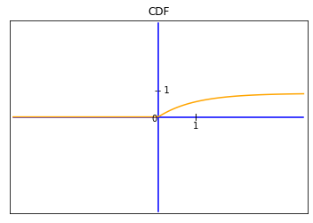

```python
import matplotlib.pyplot as plt
import numpy as np
import math

def F(x):
    y=[]
    for xx in x:
        if xx < 0:
            y.append(0)
        else:
            y.append(1-math.exp(-xx))
    return np.array(y)



x=np.linspace(-4,4,100) # Partition of interval [-4,4]

fig, ax = plt.subplots()

ax.plot([-4,4],[0,0],color='blue')
ax.plot([0,0],[-4,4],color='blue')
ax.plot(x,F(x),color='orange')
ax.text(-0.1,1,'-- 1')
ax.text(1,-0.15,'I')
ax.text(0.95,-0.5,'1')
ax.text(-0.2,-0.2,'0')
ax.set_ylim(-4.1,4.1)
ax.set_xlim(-4.1,4.1)
ax.set_xticks([])
ax.set_yticks([])

ax.set_title("CDF")
plt.show()
```

*solution:* Here we are interested in $P(1<X\le 3)=?$  
$P(1<X\le 3)=F_X(3)-F_X(1)=(1-e^{-3})-(1-e^{-1})=e^{-1}-e^{-3}=0.318$

**Theorem:** For any random variable $X$,$P(X=x)=F_X(x)-F_X(x-)$

*proof:* $P(X=x)=P^X(\{x\})$

Take $E_n=(x-\frac{1}{n},x]$, $E_{n+1}\subseteq E_{n}~\forall~n=1,2,3,...$ i.e $\{E_n\}(\searrow)$, and $\{x\}=\bigcap_{n=1}^{\infty}E_n=\lim_{n\to\infty}E_n$

$P^X(\{x\})=P^X(\lim_{n\to\infty}E_n)$  
$=\lim_{n\to\infty}P^X(E_n)$

$=\lim_{n\to\infty}P^X((x-\frac{1}{n},x])$

$=\lim_{n\to\infty}P(x-\frac{1}{n}<X\le x)$

$=\lim_{n\to\infty}(F_X(x)-F_X(x-\frac{1}{n}))=\lim_{n\to\infty}F_X(x)-\lim_{n\to\infty}F_X(x-\frac{1}{n})$

$=\lim_{n\to\infty}F_X(x)-\lim_{n\to\infty}F_X(x-\frac{1}{n})$

$=F_X(x)-F_X(x-)$ ($\because\{x-\frac{1}{n}\}$ approaching $x$ from left)

$\therefore~P(X=x)=F_X(x)-F_X(x-)$

**Corollary:**

1. If $x$ is a point of continuity of $F_X(x)$, then $P(X=x)=0$ ($\because F_X(x-)=F_X(x)$)
2. If $x$ is a point of discontinuity of $F_X(x)$, then $P(X=x)=$jump length of $F_X(x)$ at $x$ ($\because P(X=x)=F_X(x)-F_X(x-)=F_X(x+)-F_X(x-)$)
3. $P(a<X<b)=F_X(b-)-F_X(a)$

*proof*: $P(a<X<b)=P^X((a,b))$  
now, $P^X((a,b])=P^X((a,b)\cup \{b\})$

$=P^X((a,b))+P^X(\{b\})$

$P^X((a,b))= P^X((a,b])-P^X(\{b\})$

$=P(a<X\le b)-P(X=b)$

$=F_X(b)-F_X(a)-(F_X(b)-F_X(b-))=F_X(b-)-F_X(a)$

$\therefore~ P(a<X<b)=F_X(b-)-F_X(a)$

1. $P(a\le X<b)=F_X(b-)-F_X(a-)$ (Exercise)
1. $P(a\le X\le b)=F_X(b)-F_X(a-)$ (Exercise)
1. For $a<b$, If the $F_X$ is continuous at $a$ and $b$, then we have the following  
   $P(a<X\le b)=P(a\le X<b)=P(a< X< b)=P(a\le X\le b)=F_X(b)-F_X(a)$  
   ($\because~F_X(a-)=F_X(a)$ and $F_X(b-)=F_X(b)$ when we have continuity at $a,b$)

**Example**: Let $X$ be the random variable with $CDF$

$F_X(x)=\left\{\begin{matrix} 0&x<0 \\ \frac{x}{4}&0\le x<1 \\ \frac{1}{2}+\frac{x-1}{4}& 1\le x<2 \\ \frac{11}{12}& 2\le x<3 \\ 1& x\ge 3 \end{matrix}\right.$  
Sketch the graph of $F_X(x)$ and then compute  
(i)$P(X=i)$ for $i=1,2,3$  
(ii)$P(\frac{1}{2}<X<\frac{3}{2}$  
(iii)$P(0<X\le 2)$  
(iv)$P(0<X<2)$  
(v)$P(0\le X<2)$  
(vi)$P(0\le X\le2)$

*solution:*

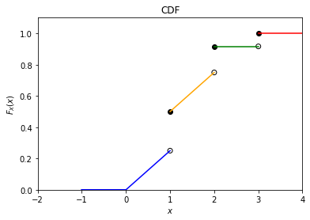

```python
import matplotlib.pyplot as plt


fig, ax = plt.subplots()
x=[0,1,2,3]
ax.scatter([1,2,3],[1/4,3/4,11/12],facecolors='none', edgecolors='black')
ax.scatter([1,2,3],[1/2,11/12,1],color='black')
ax.plot([-1,0],[0,0],color='blue')
ax.plot([-1,0,1],[0,0,1/4],color='blue')
ax.plot([1,2],[1/2,3/4],color='orange')
ax.plot([2,3],[11/12,11/12],color='green')
ax.plot([3,4],[1,1],color='red')
ax.set_xlabel('$x$')
ax.set_ylabel('$F_X(x)$')
ax.set_title("CDF")
ax.set_ylim(0,1.1)
ax.set_xlim(-2,4)

ax.set_title("CDF")
plt.show()
```

(i)  
$P(X=1)=F_X(1)-F_X(1-)=\frac{1}{2}+\frac{1-1}{4}-\frac{1}{4}=\frac{1}{4}$

$P(X=2)=F_X(2)-F_X(2-)=\frac{11}{12}-(\frac{1}{2}+\frac{2-1}{4})=\frac{1}{6}$

$P(X=3)=F_X(3)-F_X(3-)=1-\frac{11}{12}=\frac{1}{12}$

(ii)  
$P(\frac{1}{2}<X<\frac{3}{2})=F_X(\frac{3}{2}-)-F_X(\frac{1}{2})$

$=F_X(\frac{3}{2})-F_X(\frac{1}{2})$ ($\because$ $F_X(x)$ is continuous at $\frac{3}{2}$)

$=(\frac{1}{2}+\frac{\frac{3}{2}-1}{4})-\frac{\frac{1}{2}}{4}=\frac{1}{2}$

$\therefore P(\frac{1}{2}<X<\frac{3}{2})=\frac{1}{2}$

(iii) $P(0<X\le 2)=F_X(2)-F_X(0)=\frac{11}{12}-0=\frac{11}{12}$

(iv) $P(0<X<2)=F_X(2-)-F_X(0)=(\frac{1}{2}+\frac{2-1}{4})-0=\frac{3}{4}$

(v) $P(0\le X<2)=F_X(2-)-F_X(0-)=F_X(2-)-F_X(0)=\frac{3}{4}$ ($\because$ $F_X(x)$ is continuous at $0$)

(vi) $P(0<X\le 2)=F_X(2)-F_X(0-)=F_X(2)-F_X(0)=\frac{11}{12}$ ($\because$ $F_X(x)$ is continuous at $0$)